# Predicting the Winner of League of Legend's World Championship Series

## By: Richie Zhang

**Published December 12th, 2022**

**Last updated December 16th, 2022**

**Table of Contents:**

1. Introduction
2. Data Munging
   1. Reading the data
   2. Tidying and modifying data
3. Data Exploration and Analysis
4. Conclusion

### **1. Introduction:** What is League of Legends?

League of Legends (LoL) is a multiplayer online battle arena (MOBA) game developed by Riot Games. Released in October 2009, League of Legends has been around for many years and has millions of players. League of Legends hit peak concurrent players of 8 million and its competitive scene peaked at 44 million concurrent viewers during 2019.

The premise of the League's primary game, Summoner's Rift, is simple: each game consists of two teams of 5 players where players are traditionally assigned a role. There are 5 roles, Top, Jungle, Middle, Bottom and Support, with various characters (champions) to pick from for each of the role. There are currently 161 unique champions which all have unique abilities. After each team picks their champions, players are sent to their respective regions of the map. During a match, champions gain levels by accruing experience points (XP) through killing enemies and minions that spawn in each lane and the jungle. Gold is also gained upon slaying enemies and enemy structures, which allow players to buy items. Items can be acquired to increase champions' strength and are bought in one's own base. Each match is discrete, so levels and items do not transfer between matches. The winner of each game is decided by whichever team breaks the opposing team's base structure (nexus) first. More info found [here.](https://www.leagueoflegends.com/en-us/how-to-play/)

#### Summoner's Rift with Regions

[figure not shown]

League's World Champsionship Series (WCS/Worlds) is the largest annual competitive event for the game. The Worlds for 2022 started on September 29th and ended on November 5th. The event was hosted in North America and consists of games between 24 teams internationally. More information about the event can be found [here.](https://lol.fandom.com/wiki/2022_Season_World_Championship)

In this tutorial, my goal is to tidy the Worlds 2022 data that was compiled by [Oracleselixir](https://oracleselixir.com/) who scraped data from all games throughout all events using League's match history features. The compiled data gives valuable insight into which champions were strongest in terms of win rate, kill-death ratio, and gold compared to the enemy in the same lane. These stats are used to predict which champions performed well based on their stats, as well as predict whether or not a team is more likely to win due to champion selection. Champions are all unique, and each are usually assigned to their own roles. This implies various champions will gain more xp, gold, and kills overall due to their selected role. For readers unfamiliar with League, I hope this sparks interest in potentially watching the competitive scene or even playing the game by giving insight on which champions may be particularly strong. For experienced players, I hope to show interesting statistics and further insight into the nail-biter finale of Worlds 2022.

### **2. Data Munging:** Getting Started

My tutorial replies primarily on the following imported libraries: numpy, pandas, matplotlib, seaborn and scikit-learn.

```python
#Imports for project:
import numpy as np
import pandas as pd
import matplotlib.pyplot as plt
import seaborn as sns
from sklearn.model_selection import train_test_split
from sklearn.metrics import accuracy_score, log_loss
from sklearn.neighbors import KNeighborsClassifier
from sklearn.svm import SVC, LinearSVC, NuSVC
from sklearn.tree import DecisionTreeClassifier
from sklearn.ensemble import RandomForestClassifier, AdaBoostClassifier, GradientBoostingClassifier
from sklearn.naive_bayes import GaussianNB
from sklearn.discriminant_analysis import LinearDiscriminantAnalysis
from sklearn.discriminant_analysis import QuadraticDiscriminantAnalysis
from sklearn import metrics
```

### **2A. Reading the Data**

As previously mentioned, the data on the Worlds 2022 event was extracted from the match history by [Oracleselixir](https://github.com/rzhang-19/rzhang-19.github.io) , which I have uploaded to the [github repository](https://oracleselixir.com/) and extracted the url to be read. The following reads in the Worlds 2022 data and displays the extensive and detailed table.

```python
#Data imports
urll = "https://raw.githubusercontent.com/rzhang-19/rzhang-19.github.io/main/2022_LoL_esports_match_data_from_OraclesElixir_20221205.csv"
data = pd.read_csv(urll, low_memory=False)
data
```

|  | gameid | datacompleteness | url | league | year | split | playoffs | date | game | patch | ... | opp_csat15 | golddiffat15 | xpdiffat15 | csdiffat15 | killsat15 | assistsat15 | deathsat15 | opp_killsat15 | opp_assistsat15 | opp_deathsat15 |
| --- | --- | --- | --- | --- | --- | --- | --- | --- | --- | --- | --- | --- | --- | --- | --- | --- | --- | --- | --- | --- | --- |
| 0 | ESPORTSTMNT01_2690210 | complete | NaN | LCK CL | 2022 | Spring | 0 | 2022-01-10 07:44:08 | 1 | 12.01 | ... | 121.0 | 391.0 | 345.0 | 14.0 | 0.0 | 1.0 | 0.0 | 0.0 | 1.0 | 0.0 |
| 1 | ESPORTSTMNT01_2690210 | complete | NaN | LCK CL | 2022 | Spring | 0 | 2022-01-10 07:44:08 | 1 | 12.01 | ... | 100.0 | 541.0 | -275.0 | -11.0 | 2.0 | 3.0 | 2.0 | 0.0 | 5.0 | 1.0 |
| 2 | ESPORTSTMNT01_2690210 | complete | NaN | LCK CL | 2022 | Spring | 0 | 2022-01-10 07:44:08 | 1 | 12.01 | ... | 119.0 | -475.0 | 153.0 | 1.0 | 0.0 | 3.0 | 0.0 | 3.0 | 3.0 | 2.0 |
| 3 | ESPORTSTMNT01_2690210 | complete | NaN | LCK CL | 2022 | Spring | 0 | 2022-01-10 07:44:08 | 1 | 12.01 | ... | 149.0 | -793.0 | -1343.0 | -34.0 | 2.0 | 1.0 | 2.0 | 3.0 | 3.0 | 0.0 |
| 4 | ESPORTSTMNT01_2690210 | complete | NaN | LCK CL | 2022 | Spring | 0 | 2022-01-10 07:44:08 | 1 | 12.01 | ... | 21.0 | 443.0 | -497.0 | 7.0 | 1.0 | 2.0 | 2.0 | 0.0 | 6.0 | 2.0 |
| ... | ... | ... | ... | ... | ... | ... | ... | ... | ... | ... | ... | ... | ... | ... | ... | ... | ... | ... | ... | ... | ... |
| 148195 | ESPORTSTMNT03_3043835 | complete | NaN | NEXO | 2023 | Split 1 | 1 | 2022-12-04 19:11:24 | 5 | 12.21 | ... | 149.0 | -221.0 | 227.0 | -3.0 | 0.0 | 0.0 | 0.0 | 0.0 | 0.0 | 0.0 |
| 148196 | ESPORTSTMNT03_3043835 | complete | NaN | NEXO | 2023 | Split 1 | 1 | 2022-12-04 19:11:24 | 5 | 12.21 | ... | 122.0 | 561.0 | 253.0 | 20.0 | 0.0 | 1.0 | 1.0 | 2.0 | 1.0 | 0.0 |
| 148197 | ESPORTSTMNT03_3043835 | complete | NaN | NEXO | 2023 | Split 1 | 1 | 2022-12-04 19:11:24 | 5 | 12.21 | ... | 22.0 | -706.0 | 119.0 | -16.0 | 0.0 | 1.0 | 1.0 | 1.0 | 2.0 | 0.0 |
| 148198 | ESPORTSTMNT03_3043835 | complete | NaN | NEXO | 2023 | Split 1 | 1 | 2022-12-04 19:11:24 | 5 | 12.21 | ... | 489.0 | 2304.0 | 1835.0 | 67.0 | 4.0 | 4.0 | 1.0 | 1.0 | 2.0 | 4.0 |
| 148199 | ESPORTSTMNT03_3043835 | complete | NaN | NEXO | 2023 | Split 1 | 1 | 2022-12-04 19:11:24 | 5 | 12.21 | ... | 556.0 | -2304.0 | -1835.0 | -67.0 | 1.0 | 2.0 | 4.0 | 4.0 | 4.0 | 1.0 |

148200 rows × 123 columns

In the above dataset, there are over 100 columns, 123 to be precise. Most of these columns are simply more detailed columns of another column, whether it be showing the opposing team's difference in gold and xp compared to another team's during a game, or even listing off the game version and gameid.

### **2B. Modifying and Tidying the Data**

First, we want to collapse the rows of the data to focus on primarily the Worlds 2022 event. This is done through taking only the data which has a column specifying the competitive league "WCS," which indicates the World Championship Series. Furthermore, some of the data had incomplete games when looking through the data, so I extracted only the data of the Worlds 2022 games whose data was marked as "complete" instead of having missing data.

```python
#This data specifies the World Championship Series league for the LoL Worlds 2022 event.
worlds = data[data['league'] == 'WCS']

#This data specifies the completeness of data, dropping the games without properly compiled data.
worlds_complete = worlds[worlds['datacompleteness'] == 'complete']
```

#### **Removing redundant and useless data**

I first started off by removing the useless data regarding the information of the game rather than the state of the game. Among these included the gameid, completeness of data, url, league, year, split, date, and more in the first few columns

```python
#Removing Unnecessary Data about time, gameid, etc.
lst1 = [12, 15, 17]

#This second list contains data about the game's state: xp, gold, kills, deaths, etc.
lst2 = list(range(23,123))
cols = lst1 + lst2

#Creates a new list of data without the excess information about id
tidy_data = worlds_complete[worlds_complete.columns[cols]]
tidy_data
```

|  | position | teamname | champion | gamelength | result | kills | deaths | assists | teamkills | teamdeaths | ... | opp_csat15 | golddiffat15 | xpdiffat15 | csdiffat15 | killsat15 | assistsat15 | deathsat15 | opp_killsat15 | opp_assistsat15 | opp_deathsat15 |
| --- | --- | --- | --- | --- | --- | --- | --- | --- | --- | --- | --- | --- | --- | --- | --- | --- | --- | --- | --- | --- | --- |
| 130512 | top | DWG KIA | Aatrox | 1943 | 1 | 2 | 0 | 3 | 13 | 1 | ... | 129.0 | 849.0 | 878.0 | 28.0 | 0.0 | 0.0 | 0.0 | 0.0 | 0.0 | 0.0 |
| 130513 | jng | DWG KIA | Sejuani | 1943 | 1 | 3 | 1 | 8 | 13 | 1 | ... | 98.0 | 905.0 | -191.0 | -5.0 | 2.0 | 2.0 | 1.0 | 0.0 | 0.0 | 2.0 |
| 130514 | mid | DWG KIA | Swain | 1943 | 1 | 2 | 0 | 4 | 13 | 1 | ... | 145.0 | 500.0 | -79.0 | -1.0 | 1.0 | 2.0 | 0.0 | 0.0 | 0.0 | 1.0 |
| 130515 | bot | DWG KIA | Lucian | 1943 | 1 | 4 | 0 | 7 | 13 | 1 | ... | 135.0 | 497.0 | 659.0 | 0.0 | 0.0 | 5.0 | 0.0 | 1.0 | 0.0 | 1.0 |
| 130516 | sup | DWG KIA | Nami | 1943 | 1 | 2 | 0 | 9 | 13 | 1 | ... | 3.0 | 1508.0 | 223.0 | 12.0 | 2.0 | 3.0 | 0.0 | 0.0 | 1.0 | 1.0 |
| ... | ... | ... | ... | ... | ... | ... | ... | ... | ... | ... | ... | ... | ... | ... | ... | ... | ... | ... | ... | ... | ... |
| 146071 | mid | DRX | Azir | 2529 | 1 | 3 | 2 | 9 | 19 | 10 | ... | 136.0 | 310.0 | -585.0 | -3.0 | 2.0 | 0.0 | 2.0 | 0.0 | 3.0 | 2.0 |
| 146072 | bot | DRX | Caitlyn | 2529 | 1 | 5 | 0 | 4 | 19 | 10 | ... | 143.0 | -756.0 | -269.0 | -23.0 | 0.0 | 0.0 | 0.0 | 0.0 | 0.0 | 0.0 |
| 146073 | sup | DRX | Bard | 2529 | 1 | 0 | 1 | 10 | 19 | 10 | ... | 15.0 | -487.0 | 315.0 | -2.0 | 0.0 | 0.0 | 0.0 | 0.0 | 1.0 | 0.0 |
| 146074 | team | T1 | NaN | 2529 | 0 | 10 | 19 | 20 | 10 | 19 | ... | 487.0 | 433.0 | -965.0 | 15.0 | 3.0 | 5.0 | 4.0 | 4.0 | 4.0 | 3.0 |
| 146075 | team | DRX | NaN | 2529 | 1 | 19 | 10 | 37 | 19 | 10 | ... | 502.0 | -433.0 | 965.0 | -15.0 | 4.0 | 4.0 | 3.0 | 3.0 | 5.0 | 4.0 |

1692 rows × 103 columns

Next, we need to compress the data about the game state, especially since many of the columns are either repetitive or too detailed to make a difference in the outcome of the game. To do this, we take the previous data table and further extract the important columns. Since we have data from both teams, any opponent data is redundant. I wanted to particularly focus on the data regarding kills, deaths, assists, major objectives during the game (baron nashor and the dragons), as well as the state of the game at 15 minutes. The reasoning behind the data at 15 minutes is because 15 minutes is typically when players start to leave their traditional roles and regions of the map. This means that at 15 minutes, we can see how well a certain champion or team performed against another during the first 15 minutes, which is also known as the "laning phase" during a League game.

```python
#This extracts the first cluster of crucial data about kills/deaths/assists
lst1 = list(range(0,8))

#This extracts the data regarding major objectives to claim during games, gold, and monsters defeated.
lst2 = [21, 32, 35, 38, 41, 47, 61, 67]

#This extracts the data regarding the difference between gold, xp, kills, deaths, and more at 15 minutes.
lst3 = [88, 89, 90, 94, 95, 96, 97, 98, 99]

cols = lst1 + lst2 + lst3

extracted_data = tidy_data[tidy_data.columns[cols]]
extracted_data
```

|  | position | teamname | champion | gamelength | result | kills | deaths | assists | dragons | elders | ... | total cs | goldat15 | xpat15 | csat15 | golddiffat15 | xpdiffat15 | csdiffat15 | killsat15 | assistsat15 | deathsat15 |
| --- | --- | --- | --- | --- | --- | --- | --- | --- | --- | --- | --- | --- | --- | --- | --- | --- | --- | --- | --- | --- | --- |
| 130512 | top | DWG KIA | Aatrox | 1943 | 1 | 2 | 0 | 3 | NaN | NaN | ... | 320.0 | 5529.0 | 8215.0 | 157.0 | 849.0 | 878.0 | 28.0 | 0.0 | 0.0 | 0.0 |
| 130513 | jng | DWG KIA | Sejuani | 1943 | 1 | 3 | 1 | 8 | NaN | NaN | ... | 168.0 | 5426.0 | 5228.0 | 93.0 | 905.0 | -191.0 | -5.0 | 2.0 | 2.0 | 1.0 |
| 130514 | mid | DWG KIA | Swain | 1943 | 1 | 2 | 0 | 4 | NaN | NaN | ... | 247.0 | 5434.0 | 7364.0 | 144.0 | 500.0 | -79.0 | -1.0 | 1.0 | 2.0 | 0.0 |
| 130515 | bot | DWG KIA | Lucian | 1943 | 1 | 4 | 0 | 7 | NaN | NaN | ... | 321.0 | 5611.0 | 5603.0 | 135.0 | 497.0 | 659.0 | 0.0 | 0.0 | 5.0 | 0.0 |
| 130516 | sup | DWG KIA | Nami | 1943 | 1 | 2 | 0 | 9 | NaN | NaN | ... | 28.0 | 4401.0 | 4093.0 | 15.0 | 1508.0 | 223.0 | 12.0 | 2.0 | 3.0 | 0.0 |
| ... | ... | ... | ... | ... | ... | ... | ... | ... | ... | ... | ... | ... | ... | ... | ... | ... | ... | ... | ... | ... | ... |
| 146071 | mid | DRX | Azir | 2529 | 1 | 3 | 2 | 9 | NaN | NaN | ... | 387.0 | 5543.0 | 7204.0 | 133.0 | 310.0 | -585.0 | -3.0 | 2.0 | 0.0 | 2.0 |
| 146072 | bot | DRX | Caitlyn | 2529 | 1 | 5 | 0 | 4 | NaN | NaN | ... | 388.0 | 4700.0 | 5637.0 | 120.0 | -756.0 | -269.0 | -23.0 | 0.0 | 0.0 | 0.0 |
| 146073 | sup | DRX | Bard | 2529 | 1 | 0 | 1 | 10 | NaN | NaN | ... | 47.0 | 3144.0 | 3556.0 | 13.0 | -487.0 | 315.0 | -2.0 | 0.0 | 0.0 | 0.0 |
| 146074 | team | T1 | NaN | 2529 | 0 | 10 | 19 | 20 | 2.0 | 0.0 | ... | NaN | 24525.0 | 28845.0 | 502.0 | 433.0 | -965.0 | 15.0 | 3.0 | 5.0 | 4.0 |
| 146075 | team | DRX | NaN | 2529 | 1 | 19 | 10 | 37 | 5.0 | 1.0 | ... | NaN | 24092.0 | 29810.0 | 487.0 | -433.0 | 965.0 | -15.0 | 4.0 | 4.0 | 3.0 |

1692 rows × 25 columns

#### **Organizing and Modifying the data**

So now that the data has cleaned out redundant and useless data for the most part, I want to extract two things: the data regarding a team's performance during a game, and the data regarding individual champion performance during games. Thus, I decided to split up the data into team data and champion data. I also noticed some data was all 0 in parts of each, so I opted to drop the empty data in the team and champion data tables.

```python
#This data specifies each team's overall data compiled.
team_data = extracted_data[extracted_data['position'] == 'team']
team_data = team_data.drop(['total cs'], axis = 1)
team_win_data = team_data[team_data['result'] == 1]
team_lose_data = team_data[team_data['result'] == 0]

#This data specifies each individual champion's data compiled.
champion_data = extracted_data[extracted_data['position'] != 'team']

#Drops the all 0 data
champion_data = champion_data.drop(['dragons','elders','heralds','towers'], axis=1)

#Creates a new data table which compiles the champion, games won, kills, deaths, etc, and gets the # of games played
champion_data['games'] = 1
lst = champion_data.columns.values
newlist = lst[4:]
champs = champion_data.groupby(['champion','position'], as_index=False)[newlist].apply(sum)
champion_data = champion_data.drop(['games'], axis=1)

#Displays the first few champions played during Worlds 2022
champs.head()
```

|  | champion | position | result | kills | deaths | assists | barons | inhibitors | totalgold | total cs | goldat15 | xpat15 | csat15 | golddiffat15 | xpdiffat15 | csdiffat15 | killsat15 | assistsat15 | deathsat15 | games |
| --- | --- | --- | --- | --- | --- | --- | --- | --- | --- | --- | --- | --- | --- | --- | --- | --- | --- | --- | --- | --- |
| 0 | Aatrox | top | 35.0 | 171.0 | 147.0 | 293.0 | 1.0 | 7.0 | 703247.0 | 14392.0 | 290736.0 | 414972.0 | 7155.0 | 8515.0 | 16620.0 | 470.0 | 34.0 | 35.0 | 39.0 | 56.0 |
| 1 | Ahri | mid | 7.0 | 48.0 | 17.0 | 64.0 | 0.0 | 5.0 | 159202.0 | 3332.0 | 63269.0 | 81419.0 | 1616.0 | 4510.0 | -806.0 | 22.0 | 11.0 | 8.0 | 4.0 | 11.0 |
| 2 | Akali | mid | 19.0 | 144.0 | 74.0 | 128.0 | 0.0 | 2.0 | 434755.0 | 9161.0 | 185135.0 | 254449.0 | 4652.0 | 990.0 | 3724.0 | 68.0 | 40.0 | 23.0 | 16.0 | 34.0 |
| 3 | Alistar | sup | 5.0 | 4.0 | 46.0 | 107.0 | 0.0 | 0.0 | 87552.0 | 381.0 | 41919.0 | 43350.0 | 265.0 | -3761.0 | -3735.0 | 7.0 | 3.0 | 24.0 | 12.0 | 13.0 |
| 4 | Amumu | sup | 12.0 | 23.0 | 76.0 | 204.0 | 0.0 | 2.0 | 146987.0 | 678.0 | 66446.0 | 73374.0 | 452.0 | 1850.0 | 4457.0 | 67.0 | 9.0 | 51.0 | 24.0 | 19.0 |

Now that the data is tidy and cleaned of excess information, we can now compute the two datasets to compare champion performance during Worlds 2022, and determine whether or not the winner of Worlds 2022 is correctly identified.

### **3. Data Exploration and Analysis**

For this section, I want to see how impactful each of the columns are in terms of the influencing a win in a game, which is why I decided to first explore a heat map of the original champion_data table prior to combining champion data. This allows for me to explore and analyze which parts of the game are most impactful.

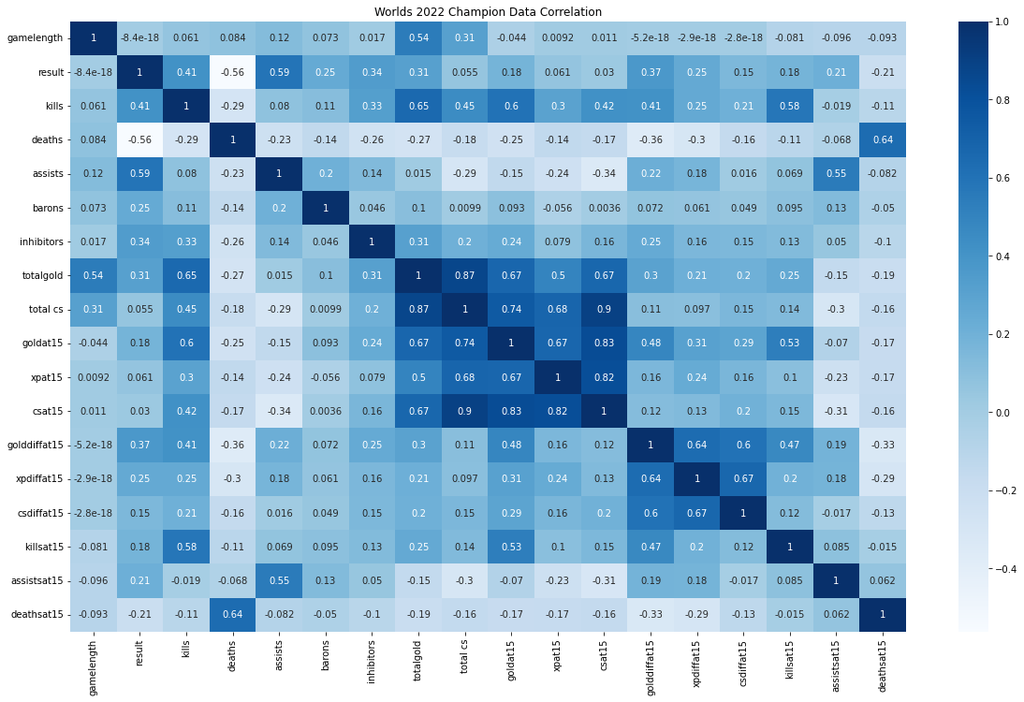

```python
#Heatmap Correlation of champion_data
plt.figure(figsize = (20,12))
sns.heatmap(champion_data.corr(), annot = True, cmap = 'Blues')
plt.title("Worlds 2022 Champion Data Correlation")
plt.show()
```

From looking at the correlation heatmap of our champion_data table, we can see in the results row, there is a greater positive correlation between kills and assists. Furthermore, there is a large negative correlation between deaths and the result of a game as well. This correlation in the heatmap implies that there is likely a correlation between the Kills to Death to Assists (KDA) ratio and the win rate of champions.

#### **Graphing Kills+Assist-Death vs. Win Ratio (by Position)**

- I used the champs data table in this case since I wanted to analyze each champion's collective kills/assists/deaths and win rate.

There are a multitude of champions and positions which the players of League can choose from, so I decided to further split the champs data table by position, as well as deprecate any champion data which had less than 5 games played total. Having less than 5 games played total could perhaps skew the data representation and cause an incorrect analysis of the data, especially since there would be under-representation of a champion. Furthermore, having less than 5 games played for a champion in a specific role could be due to an off meta (most effective tactic available) pick, where these champion selections are abnormalities to the traditional roles. I also calculated another value which sums kills and assists and divides by death, otherwise known as KDA. To obtain win rate, I calculated result divided by games, which is a champion's win percentage.

[figure not shown]

```python
#Calculates each champion's respective KDA and win rate
lst = (champs['kills'] + champs['assists']) / champs['deaths']
lst2 = champs['result'] / champs['games']
champs['kda'] = lst
champs['win_rate'] = lst2

#Drops the champions with games under 5
champs_meta = champs[champs['games'] >= 5]

#Get the champion data based on each role: top, jng, mid, bot, sup
top = champs_meta[champs_meta['position'] == 'top']
jungle = champs_meta[champs_meta['position'] == 'jng']
mid = champs_meta[champs_meta['position'] == 'mid']
bot = champs_meta[champs_meta['position'] == 'bot']
sup = champs_meta[champs_meta['position'] == 'sup']
```

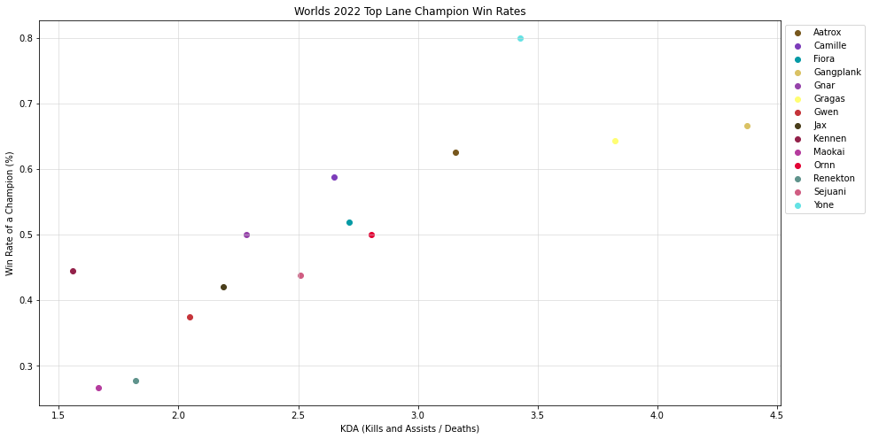

```python
#Graphing top lane kda vs win-rates
plt.figure(figsize=(15,8))
plt.xlabel('KDA (Kills and Assists / Deaths)')
plt.ylabel('Win Rate of a Champion (%)')
plt.title('Worlds 2022 Top Lane Champion Win Rates')
plt.grid(color='lightgray', alpha=0.75, zorder=1)
plt.grid(True)
for c in top['champion'].unique():
    temp = top[top['champion'] == c]
    kda = temp['kda']
    win_rate = temp['win_rate']
    plt.scatter(kda, win_rate, color=np.random.rand(3,), label=c)
plt.legend(bbox_to_anchor=(1,1), loc=2);
```

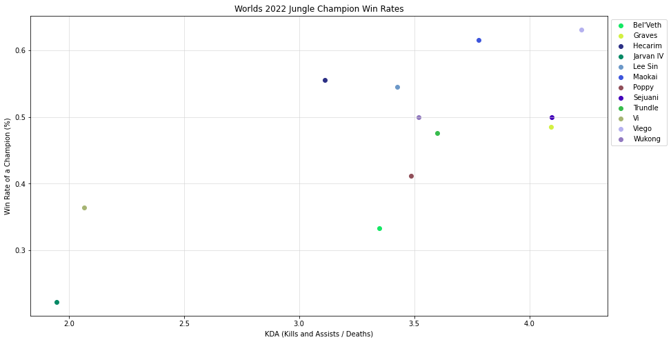

```python
#Graphing Jungle kda vs win-rates
plt.figure(figsize=(15,8))
plt.xlabel('KDA (Kills and Assists / Deaths)')
plt.ylabel('Win Rate of a Champion (%)')
plt.title('Worlds 2022 Jungle Champion Win Rates')
plt.grid(color='lightgray', alpha=0.75, zorder=1)
plt.grid(True)
for c in jungle['champion'].unique():
    temp = jungle[jungle['champion'] == c]
    kda = temp['kda']
    win_rate = temp['win_rate']
    plt.scatter(kda, win_rate, color=np.random.rand(3,), label=c)
plt.legend(bbox_to_anchor=(1,1), loc=2);
```

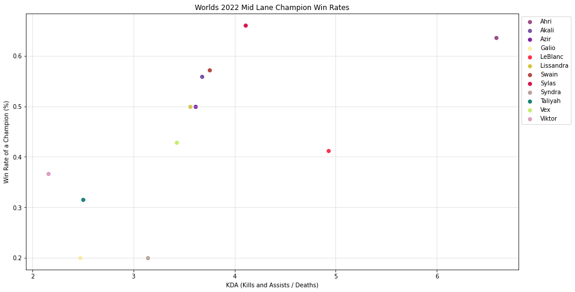

```python
#Graphing Mid lane kda vs win-rates
plt.figure(figsize=(15,8))
plt.xlabel('KDA (Kills and Assists / Deaths)')
plt.ylabel('Win Rate of a Champion (%)')
plt.title('Worlds 2022 Mid Lane Champion Win Rates')
plt.grid(color='lightgray', alpha=0.75, zorder=1)
plt.grid(True)
for c in mid['champion'].unique():
    temp = mid[mid['champion'] == c]
    kda = temp['kda']
    win_rate = temp['win_rate']
    plt.scatter(kda, win_rate, color=np.random.rand(3,), label=c)
plt.legend(bbox_to_anchor=(1,1), loc=2);
```

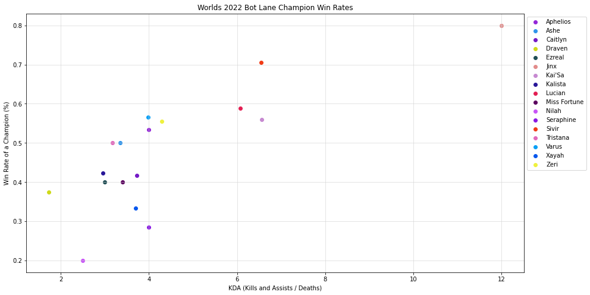

```python
#Graphing Bot lane kda vs win-rates
plt.figure(figsize=(15,8))
plt.xlabel('KDA (Kills and Assists / Deaths)')
plt.ylabel('Win Rate of a Champion (%)')
plt.title('Worlds 2022 Bot Lane Champion Win Rates')
plt.grid(color='lightgray', alpha=0.75, zorder=1)
plt.grid(True)
for c in bot['champion'].unique():
    temp = bot[bot['champion'] == c]
    kda = temp['kda']
    win_rate = temp['win_rate']
    plt.scatter(kda, win_rate, color=np.random.rand(3,), label=c)
plt.legend(bbox_to_anchor=(1,1), loc=2);
```

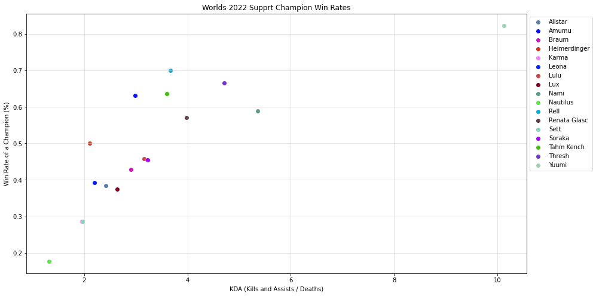

```python
#Graphing Support kda vs win-rates
plt.figure(figsize=(15,8))
plt.xlabel('KDA (Kills and Assists / Deaths)')
plt.ylabel('Win Rate of a Champion (%)')
plt.title('Worlds 2022 Supprt Champion Win Rates')
plt.grid(color='lightgray', alpha=0.75, zorder=1)
plt.grid(True)
for c in sup['champion'].unique():
    temp = sup[sup['champion'] == c]
    kda = temp['kda']
    win_rate = temp['win_rate']
    plt.scatter(kda, win_rate, color=np.random.rand(3,), label=c)
plt.legend(bbox_to_anchor=(1,1), loc=2);
```